# scRNA-seq Simulation Comparison

Joey Hastings

2023-01-11

The purpose of this page is to compare the performance of different scRNA-seq simulation packages to the count data from which they are derived.

Install non-CRAN packages if necessary:

```r
if (!require(devtools)) install.packages("devtools")
devtools::install_github("UcarLab/IA-SVA")
devtools::install_github("dleelab/iasvaExamples")
devtools::install_github("JSB-UCLA/scDesign2")

if (!require(BiocManager)) install.packages("BiocManager")
BiocManager::install("splatter")
```

## Load packages

```r
library(iasva)
library(iasvaExamples) # for data
library(splatter)
library(scDesign2)
library(tidyverse)
```

## Load islet single-cell RNA-Seq data

We load the islet scRNA-seq data and place the count matrix into `counts`. The column names are replaced with the corresponding cell type from the annotations data, `anns`.

```r
data("Lawlor_Islet_scRNAseq_Read_Counts")
data("Lawlor_Islet_scRNAseq_Annotations")

counts <- Lawlor_Islet_scRNAseq_Read_Counts
anns <- Lawlor_Islet_scRNAseq_Annotations

colnames(counts) <- anns$cell.type
cell_types <- unique(anns$cell.type)
cell_type_prob <- table(anns$cell.type) / sum(table(anns$cell.type))

# Dimension of original count data
dim(counts)
```

```
## [1] 26542   638
```

```r
# Unique cell types
cell_types
```

```
## [1] "INS"    "GCG"    "SST"    "COL1A1" "PPY"    "KRT19"  "PRSS1"  "none"
```

## Simulate via `splatter`

- [Paper](https://doi.org/10.1186/s13059-017-1305-0)
- [Site](https://bioconductor.org/packages/release/bioc/html/splatter.html)

`splatter` uses a count matrix to estimate parameters. Cell groups proportions from the original data are used to generate cell types in similar proportions in the simulated data. The number of genes and cells simulated are the same as the original count matrix if not explicitly changed.

```r
# Note: this cell is not knitted in the interest of saving time
# Results are loaded in the next cell

# Fit model from original count data
set.seed(1)
splatter_params <- splatEstimate(
  counts,
  params = newSplatParams(
    group.prob = as.numeric(cell_type_prob)
    )
  )

# Simulate new data
splatter_sim <- splatSimulate(
  splatter_params,
  method = "groups",
  group.prob = as.numeric(cell_type_prob)
  )

saveRDS(splatter_params, file = "splatter_params.rds")
saveRDS(splatter_sim, file = "splatter_sim.rds")
```

Estimated parameters:

```r
splatter_params <- readRDS("splatter_params.rds")
splatter_params
```

```
## A Params object of class SplatParams
## Parameters can be (estimable) or [not estimable], 'Default' or  'NOT DEFAULT'
## Secondary parameters are usually set during simulation
##
## Global:
## (GENES)  (CELLS)   [SEED]
##   26542      638   548676
##
## 29 additional parameters
##
## Batches:
##     [BATCHES]  [BATCH CELLS]     [Location]        [Scale]       [Remove]
##             1            638            0.1            0.1          FALSE
##
## Mean:
##              (RATE)              (SHAPE)
## 0.00945973972488717    0.347165453182876
##
## Library size:
##        (LOCATION)            (SCALE)             (Norm)
##   14.211816548204  0.373950762018051              FALSE
##
## Exprs outliers:
##       (PROBABILITY)           (LOCATION)              (SCALE)
## 0.00221708116444959     6.16239157920417     1.02202096267411
##
## Groups:
##                                                                         [GROUPS]                                                                     [GROUP PROBS]
##                                                                                8  0.0297805642633229, 0.374608150470219, 0.413793103448276, 0.0438871473354232,...
##
## Diff expr:
## [Probability]    [Down Prob]     [Location]        [Scale]
##           0.1            0.5            0.1            0.4
##
## BCV:
##    (COMMON DISP)             (DOF)
## 1.77875983813633  7.92800399660235
##
## Dropout:
##             [Type]          (MIDPOINT)             (SHAPE)
##               none    2.97710699226543  -0.699472793274739
##
## Paths:
##         [From]         [Steps]          [Skew]    [Non-linear]  [Sigma Factor]
##              0             100             0.5             0.1             0.8
```

```r
splatter_sim <- readRDS("splatter_sim.rds")

# Dimension of simulated data
dim(counts(splatter_sim))
```

```
## [1] 26542   638
```

## Simulate via `scDesign2`

- [Paper](https://doi.org/10.1186/s13059-021-02367-2)
- [Site](https://github.com/JSB-UCLA/scDesign2)

`scDesign2` also uses a count matrix to estimate distribution parameters. The `cell_types` function parameter specifies which cell types are to be used to fit the models. The simulation method of `copula` will simulate gene models that have dependent marginal distributions.

The simulation function requires a model parameter object (`copula_result`), the number of cells to simulate (number of columns in `counts`), the simulation method used in model fitting (`copula`), and the proportion of cell types to generate (`cell_type_prob`).

```r
# Note: this cell is not knitted in the interest of saving time
# Results are loaded in the next cell

# Fit model using a copula
RNGkind("L'Ecuyer-CMRG")
set.seed(1)

copula_result <- fit_model_scDesign2(
  counts,
  cell_types,
  sim_method = "copula"
  )

# Simulate data using a copula
sim_count_copula <- simulate_count_scDesign2(
  copula_result,
  ncol(counts),
  sim_method = "copula",
  cell_type_prop = cell_type_prob
  )

saveRDS(copula_result, file = "copula_result.rds")
saveRDS(sim_count_copula, file = "sim_count_copula.rds")
```

```r
# copula_result <- readRDS("copula_result.rds")
sim_count_copula <- readRDS("sim_count_copula.rds")

# Dimension of simulated data
dim(sim_count_copula)
```

```
## [1] 26542   638
```

## Comparison of Data

The `splatter` package provides some excellent utility functions to compare common metrics used in scRNA-seq analysis. The original data and simulated data from `scDesign2` are converted to `SingleCellExperiment` (SCE) objects (note: the default object from a `splatter` simulation is an SCE). The `compareSCEs` function calculates various statistics for the genes/cells as well as generating multiple plots.

```r
orig_sce <- SingleCellExperiment(list(counts=counts))
scdesign2_sce <- SingleCellExperiment(list(counts=sim_count_copula))

comparison <- compareSCEs(list(Original = orig_sce, Splat = splatter_sim, scDesign2 = scdesign2_sce))
```

## Visualizations of Data

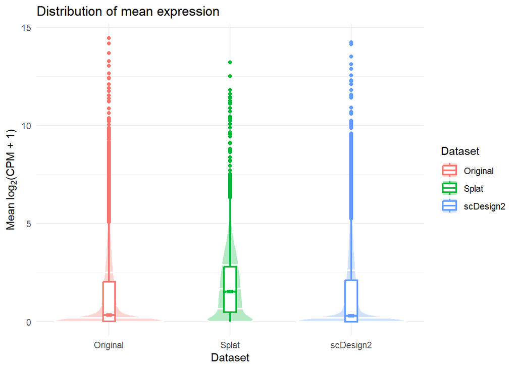

```r
# Boxplot of mean distribution
comparison$Plots$Means
```

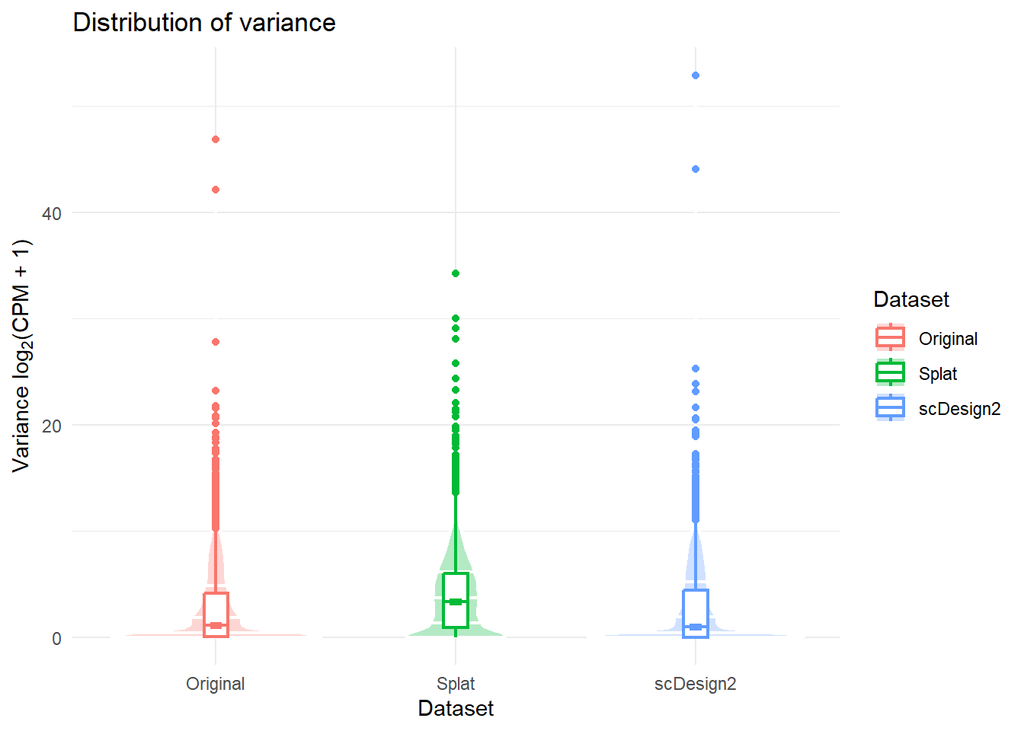

```r
# Boxplot of variance distribution
comparison$Plots$Variances
```

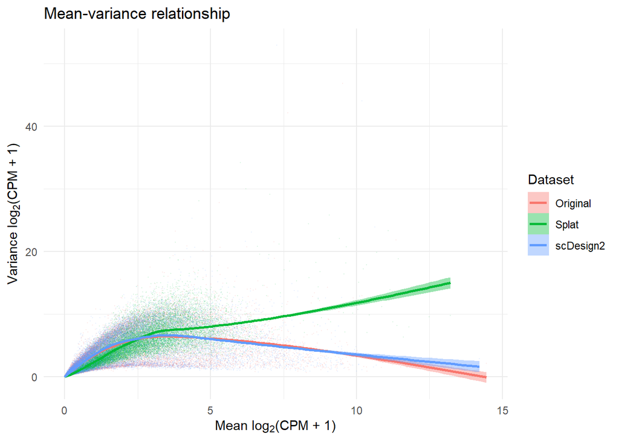

```r
# Scatter plot with fitted lines showing the mean-variance relationship
comparison$Plots$MeanVar
```

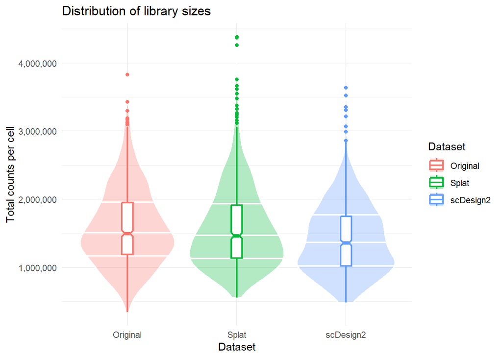

```r
# Boxplot of the library size distribution
comparison$Plots$LibrarySizes
```

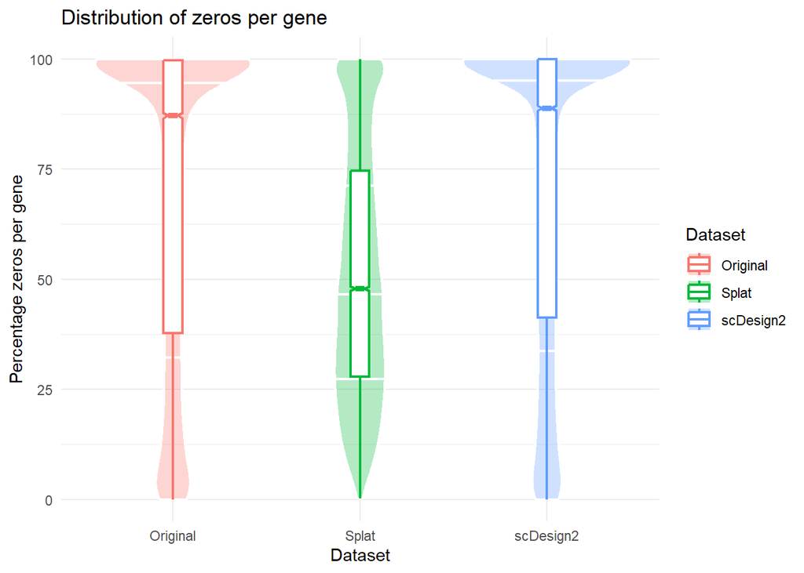

```r
# Boxplot of the percentage of each gene that is zero
comparison$Plots$ZerosGene
```

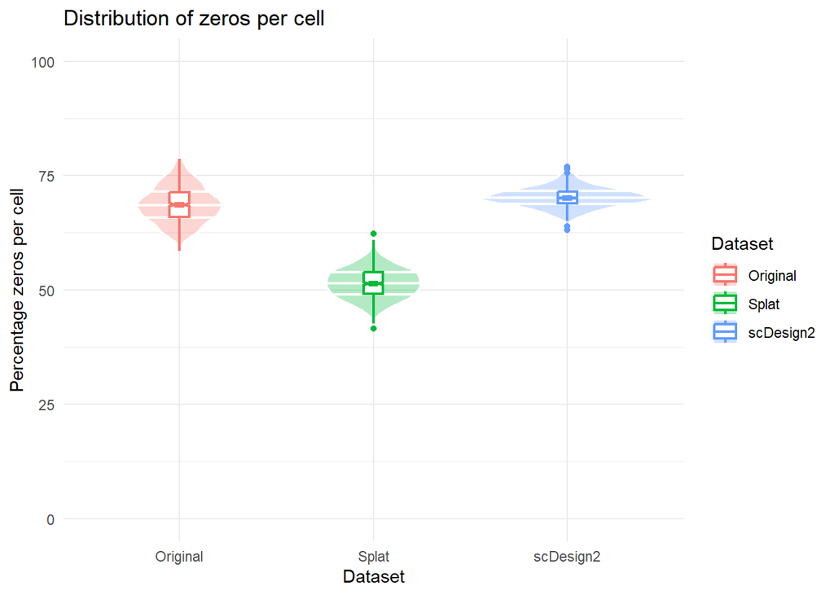

```r
# Boxplot of the percentage of each cell that is zero
comparison$Plots$ZerosCell
```

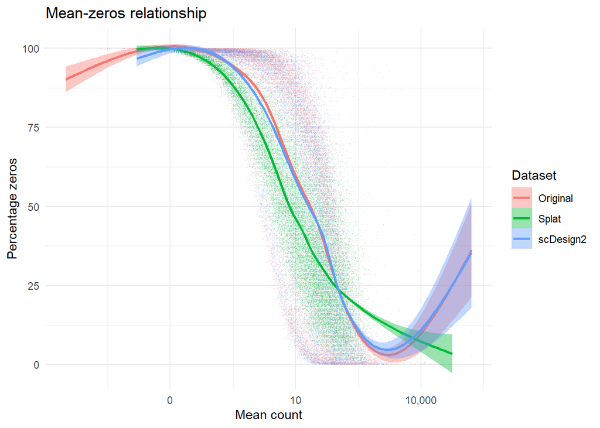

```r
# Scatter plot with fitted lines showing the mean-zeros relationship
comparison$Plots$MeanZeros
```

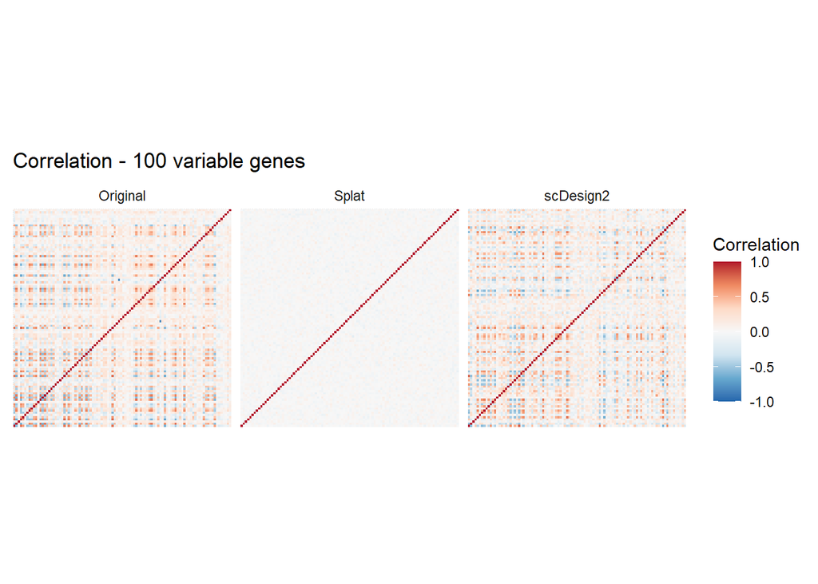

```r
# Heatmap of correlation of the 100 most variable genes
comparison$Plots$VarGeneCor
```